# Human Activity Recognition

Francisco J. Valverde-Albacete

23 de enero de 2015

# Executive Summary

We studied classification trees (CT), bagged CT, boosted CT, random forests, and linear discriminant analysis on a task of multiclass weight lifting classification.

The models were all fitted by 5-fold cross validation and some of them had their own inherent resampling features. All other parameters were set to the default provided by the caret package (v. 6.0-41).

The bagged/boosted models were signiticatively superior to the non-bagged/boosted ones. The differences between the best two are not significant. We choose a bagged tree model for predictions.

# Development

## Prelude: data loading and transformation

```r
library(plyr);library(dplyr); library(ggplot2); library(caret)
# Load the data
training <- read.csv("pml-training.csv",
                     header=TRUE,
                     na.strings=c("NA","", "#DIV/0!")
                     )
testing <- read.csv("pml-testing.csv",
                     header=TRUE,
                     na.strings=c("NA","", "#DIV/0!")
                     )
dim(training)
```

```
## [1] 19622   160
```

```r
dim(testing)
```

```
## [1]  20 160
```

There is a number of problems with these data:

1. Some columns should not be used for prediction, since they are arbitrary, like observation numbers, timestamps, user names

```r
deletedColumns <- c("X", "user_name", "new_window", names(training)[grep("timestamp", names(training))])
```

2. There is an enormous proportion of NA values. They are differently encoded as: “NA”, “#DIV/0!” or simply absent (“”) in the original data. We delete all of those columns which are all NAs, or have zero variance.

Note that we also observe *some data* in the test set, only to discard it! That is, the retained information in the test set has still not been seen in model development.

```r
print(sprintf("The proportion of NA in training values is rather high: %0.2f",
    sum(is.na(training))/(prod(dim(training)))))
```

```
## [1] "The proportion of NA in training values is rather high: 0.61"
```

```r
print(sprintf("and also for testing: %0.2f",
              sum(is.na(testing))/(prod(dim(testing)))))
```

```
## [1] "and also for testing: 0.62"
```

```r
#Some columns are completely filled with NAs
deletedColumns <- union(
    union(deletedColumns,
          names(which(unlist(lapply(testing, function(x)all(is.na(x))))))),
    union(
        names(which(unlist(lapply(training, function(x)all(is.na(x)))))),
        names(which(unlist(lapply(training,
                            function(x)is.numeric(x) & var(x, na.rm=TRUE)==0.0))))
        )
    )
```

3. There may be data-collection artifacts: combinations of predictors which imply the classe or variables with zero variance

We retain only those columns not marked for deletion

```r
preTraining <- dplyr::select(training, -one_of(deletedColumns))
preTesting <- dplyr::select(testing, -one_of(deletedColumns))
dim(preTraining)
```

```
## [1] 19622    54
```

```r
dim(preTesting)
```

```
## [1] 20 54
```

## Preliminary analysis and biases

1. The training set is slightly unbalanced towards class $A$ (well-done exercises.)

```r
# Have a look at the distribution of the classes in the training set.
summary(preTraining$classe)
```

```
##    A    B    C    D    E
## 5580 3797 3422 3216 3607
```

2. Since the data set is still to big for the more demanding techniques, we subsample:

```r
selected <- createDataPartition(y=preTraining$classe, p=0.3, list=FALSE)
preTraining <- preTraining[selected, ]
dim(preTraining)
```

```
## [1] 5889   54
```

3. We tried some preprocessing in earlier versions, but this provided no advantages, so we have avoided it in the final version.

## Exploratory Analysis: Model construction

In prediction exploratory analysis takes the form of fitting several different models to the task and then choosing one based in the performance on the training set.

```r
numMethods <- 6
n <- 1
methodsNames <- replicate(numMethods,"")
accuracies <- replicate(numMethods,0.0)
accSd <- replicate(numMethods,0.0)
# We are using repeated cross-validation
trControl <- trainControl(
    method="cv", #repeatedc #too costly
    number=5, # 5-fold cv
#    classProbs=TRUE # Provide class probabilities
    )
```

### Classification Trees

1. CART trees: plain, bagged and boosted.

```r
# set seed to the same, always
set.seed(1235)
library(rpart)
# Use CART for starters... It's too complicated to start doing feature selection.
CARTfit <- train(classe ~ ., data=preTraining,
                   method="rpart",
                   trControl=trControl
                   )
#CARTfit
methodsNames[n] <- "ctree"
accuracies[n] <- CARTfit$results[1,2]
accSd[n] <- CARTfit$results[1,4]
n <- n + 1
#Bagged trees
library(ipred)
set.seed(1235)
BaggedCARTfit <- train(classe ~ ., data=preTraining,
                       method="treebag",
                       trControl=trControl
                       )
#BaggedCARTfit
methodsNames[n] <- "Bagged ctree"
accuracies[n] <- BaggedCARTfit$results[1,2]
accSd[n] <- BaggedCARTfit$results[1,4]
n <- n + 1
#Boosted CART trees
set.seed(1235)
library(survival); library(splines); library(gbm)
BoostedCARTfit <-
    train(classe ~ ., data=preTraining,
          method="gbm",
          trControl=trControl,
          verbose=FALSE #  for gbm
          )
methodsNames[n] <- "Boosted ctree"
accuracies[n] <- BoostedCARTfit$results[9,4]
accSd[n] <- BoostedCARTfit$results[9,6]
n <- n + 1
```

We also try trees with bagging under the guise of a random forest:

```r
library(randomForest)
set.seed(1235)
rfFit <- train(classe ~ .,
               data=preTraining,
               method="rf",
               trControl=trControl, # Same one since it is only cv.
               prox=TRUE, allowParallel=TRUE,
               verbose=TRUE
               )
methodsNames[n] <- "rf"
accuracies[n] <- rfFit$results[1,2]
accSd[n] <- rfFit$results[1,4]
n <- n + 1
```

## Model-based prediction

For comparison we usa a plain linear discriminant analysis.

```r
# Linear discriminant analysis
library(MASS)
set.seed(1235)
ldaFit <- train(classe ~ .,
                data=preTraining,
                method="lda",
                trControl=trControl # only cv.
                )
#ldaFit
methodsNames[n] <- "lda"
accuracies[n] <- ldaFit$results[1,2]
accSd[n] <- ldaFit$results[1,4]
#n <- n + 1
# Naive Bayes
# library(klaR)
# set.seed(1235)
# nbFit <- train(classe ~ .,
#                 data=preTraining,
#                 method="nb",
#                 trControl=trControl # only cv.
#                 )
# #nbFit
# methodsNames[n] <- "nb"
# accuracies[n] <- nbFit$results[2,3]
# accSd[n] <- nbFit$results[2,5]
#n <- n + 1
```

## Final exploration

We plot the accuracies vs the methods:

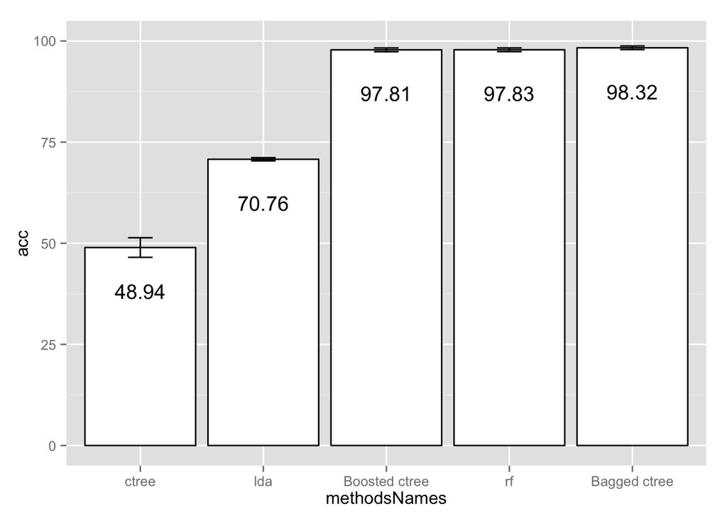

```r
results <- data.frame(methodsNames,acc=round(100*accuracies,2), accSd=round(100*accSd,2))
results <- results[1:n, ]
results$methodsNames <- with(results, reorder(methodsNames,acc))
ggplot(results, aes(x=methodsNames, y=acc)) + ylim(0,100.0)  +
    geom_bar(stat="identity", fill="white", colour="black") +
    geom_text(aes(label=acc), vjust=3.5) +
    geom_errorbar(aes(ymin=acc-accSd, ymax=acc+accSd), width=.2)
```

## Prediction

In predictive analysis, the last step is predicting and reporting the predictions. Note that there can be no assessment of these predictions!

```r
# We choose the highest accuracy, although this is not authoritative, given the variances.
best <- which.max(results$acc)  # Decide on the best method to predic
print(sprintf("The best accuracy is attained by %s", results$methodsNames[best]))
```

```
## [1] "The best accuracy is attained by Bagged ctree"
```

```r
modelFit <- BaggedCARTfit
modelFit
```

```
## Bagged CART
##
## 5889 samples
##   53 predictor
##    5 classes: 'A', 'B', 'C', 'D', 'E'
##
## No pre-processing
## Resampling: Cross-Validated (5 fold)
##
## Summary of sample sizes: 4712, 4712, 4710, 4711, 4711
##
## Resampling results
##
##   Accuracy   Kappa     Accuracy SD  Kappa SD
##   0.9831881  0.978733  0.004473076  0.005657598
##
##
```

```r
modelFit$finalModel
```

```
##
## Bagging classification trees with 25 bootstrap replications
```

```r
predictions <- predict(modelFit, preTesting)  # predictions for submission
predictions
```

```
##  [1] B B B A E E E B B E D E E A E B E A E E
## Levels: A B C D E
```

```r
# write the solutions
pml_write_files <- function(x){
  n = length(x)
  for(i in 1:n){
    filename = paste0("problem_id_",i,".txt")
    write.table(x[i],file=filename,quote=FALSE,row.names=FALSE,col.names=FALSE)
  }
}
pml_write_files(predictions)
```